# CS 8321 Lab 1

## By: Abdul Wasay, Aitor Elfau, Sam Yao

## Age Bias in AI/ML

The following notebook is adapted from the notebook shared in class by Dr. Larson as part of the 8321 course (https://github.com/8000net/LectureNotesMaster/blob/master/01%20ConceptNet.ipynb) that was originally adapted from Dr. Robyn Speer http://blog.conceptnet.io/posts/2017/how-to-make-a-racist-ai-without-really-trying/

### **1. Present an overview for what type of bias you will be investigating and why the particular investigation you will be doing is relevant. You might consider asking questions like: Why is it important to find this kind of bias in machine learning models? Why will the type of investigation I am performing be relevant to other researchers or practitioners?**

Sources to look at: https://dgergle.soc.northwestern.edu/resources/pn3458-diazA.pdf

We will be investigating age bias in ML models. This is relevant because ageism, or discrimination based on age, pervades many facets of American society. For example, in hiring in the tech industry, older applicants are typically rejected in favor of younger applicants [*https://online.ucpress.edu/collabra/article/9/1/82194/197046/Ageism-in-Hiring-A-Systematic-Review-and-Meta*]. Although there is more research towards ageism skewing for the older generation, we would also like to know if there are instances where the younger demographic may be feeling its adverse effects as well.

Why is it important to find this kind of bias in ML models? As hiring becomes more automated and utilizes AI/ML to sort through applicants, AI Models could potentially screen out applicants if they use language associated with older people by giving phrases with older language patterns a negative score.

For example, if a resume contained the words "Raised sales averages by 110% through rizzing up an average of 150 customers per day", the resume holder is likely to be a member of Gen Z and not Gen X.

On the other hand, if a resume contains the fact that the jobseeker graduated college in the 1970's, the AI model could flag this to the detriment of the jobseeker, meaning that this jobseeker would be filtered out because the model judged that they were not a good candidate based on using language more likely to be used by older jobseekers.

The type of investigation is relevant to other researchers because there is a growing field of interest in the intersection of social justice and AI/ML. Because the data that society generates can reflect social biases, AI/ML models that are trained on this data will enforce these biases as well. Therefore, researchers in Computer Science, Sociology, and even Law could find this sort of research to be relevant to what they are studying.

### **3. As part of your assignment, you will choose a methodology that involves comparing two (or more) techniques to one another. Discuss how you will measure a difference between the two techniques. That is, if you are measuring the difference statistically, what test will you use and why is it appropriate? Are there any limitations to performing this test that you should be aware of?**

A paired t-test is appropriate here because we're comparing two sets of related measurements (sentiment scores from two lexicons for the same set of words). This test will help us determine if there is a statistically significant difference in the average sentiment scores provided by the two lexicons.

### Step 1 Word Embeddings

```python
import numpy as np
import pandas as pd
import matplotlib
import seaborn
import re
import nltk
from sklearn.linear_model import SGDClassifier
from sklearn.model_selection import train_test_split
from sklearn.metrics import accuracy_score

%matplotlib inline
seaborn.set_context('notebook', rc={'figure.figsize': (10, 6)}, font_scale=1.5)
```

We use `glove.840B.300d.zip` because of its vast size and large imbedding dimensions. This should lead to better contextual understanding for the words we are going to test.

```python
%%time
def load_embeddings(filename):
    """
    Load a DataFrame from the generalized text format used by word2vec, GloVe,
    fastText, and ConceptNet Numberbatch. The main point where they differ is
    whether there is an initial line with the dimensions of the matrix.
    """
    labels = []
    rows = []
    with open(filename, encoding='utf-8') as infile:
        for i, line in enumerate(infile):
            items = line.rstrip().split(' ')
            if len(items) == 2:
                # This is a header row giving the shape of the matrix
                continue
            labels.append(items[0])
            values = np.array([float(x) for x in items[1:]], 'f')
            rows.append(values)

    arr = np.vstack(rows)
    return pd.DataFrame(arr, index=labels, dtype='f')

embeddings = load_embeddings('data/glove.840B.300d.txt')
embeddings.shape
```

```
CPU times: user 1min 9s, sys: 6.26 s, total: 1min 15s
Wall time: 1min 46s
```

```
(2196018, 300)
```

### Step 2: Add sentiment Lexicon

We use Lexicon (Hu and Liu, 2004), and define how to read these files, and read them in as the `pos_words` and `neg_words` variables:

```python
def load_lexicon(filename):

    lexicon = []
    with open(filename, encoding='latin-1') as infile:
        for line in infile:
            line = line.rstrip()
            if line and not line.startswith(';'):
                lexicon.append(line)
    return lexicon

pos_words = load_lexicon('data/positive-words.txt')
neg_words = load_lexicon('data/negative-words.txt')

print(len(pos_words), len(neg_words))
```

```
2006 4783
```

### Step 3 Train a model to predict word sentiments

Our data points here are the embeddings of these positive and negative words. We use the Pandas `.loc[]` operation to look up the embeddings of all the words.

Some of these words are not in the GloVe vocabulary, particularly the misspellings such as "fancinating". Therefore we remove them before indexing into the embedding.

```python
pos_words_common = list(set(pos_words) & set(embeddings.index))
neg_words_common = list(set(neg_words) & set(embeddings.index))

pos_vectors = embeddings.loc[pos_words_common]
neg_vectors = embeddings.loc[neg_words_common]
print(pos_vectors.shape,neg_vectors.shape)
```

```
(1974, 300) (4642, 300)
```

Now we make arrays of the desired inputs and outputs. The inputs are the embeddings, and the outputs are 1 for positive words and -1 for negative words. We also make sure to keep track of the words they're labeled with, so we can interpret the results.

```python
vectors = pd.concat([pos_vectors, neg_vectors])
targets = np.array([1 for entry in pos_vectors.index] + [-1 for entry in neg_vectors.index])
labels = list(pos_vectors.index) + list(neg_vectors.index)
```

Using the scikit-learn `train_test_split` function, we simultaneously separate the input vectors, output values, and labels into training and test data, with 10% of the data used for testing.

```python
train_vectors, test_vectors, train_targets, test_targets, train_labels, test_labels = \
    train_test_split(vectors, targets, labels, test_size=0.1, random_state=0)
```

Now we make our classifier, and train it by running the training vectors through it for 100 iterations. We use a logistic function as the loss, so that the resulting classifier can output the probability that a word is positive or negative.

```python
# create a linear classifier
model = SGDClassifier(loss='log_loss', random_state=0, max_iter=100)
model.fit(train_vectors, train_targets)
accuracy_score(model.predict(test_vectors), test_targets)
```

```
0.9365558912386707
```

Function to see the sentiment that this classifier predicts for particular words

```python
def vecs_to_sentiment(vecs):
    # predict_log_proba gives the log probability for each class
    predictions = model.predict_log_proba(vecs)

    # To see an overall positive vs. negative classification in one number,
    # we take the log probability of positive sentiment minus the log
    # probability of negative sentiment.
    # this is a logarithm of the max margin for the classifier,
    # similar to odds ratio (but not exact) log(p_1/p_0) = log(p_1)-log(p_0)
    return predictions[:, 1] - predictions[:, 0]


# def words_to_sentiment(words):
#     vecs = embeddings.loc[words].dropna()
#     log_odds = vecs_to_sentiment(vecs)
#     return pd.DataFrame({'sentiment': log_odds}, index=vecs.index)
def words_to_sentiment(words):
    vecs = embeddings.loc[words].dropna()
    log_odds = vecs_to_sentiment(vecs)
    # Reset the index to turn the index (words) into a column
    df = pd.DataFrame({'sentiment': log_odds}, index=vecs.index).reset_index()
    # Rename the index column to 'word'
    df = df.rename(columns={'index': 'word'})
    return df

# Show 20 examples from the test set
words_to_sentiment(test_labels).iloc[:20]
```

|  | word | sentiment |
| --- | --- | --- |
| 0 | vulnerable | -7.272587 |
| 1 | tempting | -2.131113 |
| 2 | irk | -10.648705 |
| 3 | risk | -7.704378 |
| 4 | wholesome | 15.818208 |
| 5 | enrapture | 5.497094 |
| 6 | efficacious | 11.484425 |
| 7 | officious | -13.295381 |
| 8 | straining | -11.330341 |
| 9 | anger | -12.329102 |
| 10 | irreversible | -7.726865 |
| 11 | dishonestly | -11.270945 |
| 12 | heartwarming | 12.346467 |
| 13 | distressing | -14.857122 |
| 14 | inelegance | -8.214031 |
| 15 | untouched | 1.603668 |
| 16 | primitive | -5.247834 |
| 17 | leakage | -11.819835 |
| 18 | insecure | -15.640644 |
| 19 | like | -0.672577 |

### Step 4: Get a sentiment score for text

There are many ways to combine sentiments for word vectors into an overall sentiment score. Again, because we're following the path of least resistance, we're just going to average them.

```python
import re
TOKEN_RE = re.compile(r"\w.*?\b")
# The regex above finds tokens that start with a word-like character (\w), and continues
# matching characters (.+?) until the next word break (\b). It's a relatively simple
# expression that manages to extract something very much like words from text.


def text_to_sentiment(text):
    # tokenize the input phrase
    tokens = [token.casefold() for token in TOKEN_RE.findall(text)]
    # send each token separately into the embedding, then the classifier
    sentiments = words_to_sentiment(tokens)
    return sentiments['sentiment'].mean() # return the mean for the classifier
```

```python
text_to_sentiment("SMU machine learning is pretty cool")
```

```
3.402755608850447
```

```python
text_to_sentiment("SMU machine learning is okay")
```

```
1.458742506000784
```

```python
text_to_sentiment("meh, SMU machine learning sucks")
```

```
-1.4959396653439734
```

### **4 (from grading ruberic). Carryout your analysis and model training. Explain your steps in as much detail so that the instructor can understand your code.

## Step 5: Test Age Bias

Below are lists created to show positive and negative words used throughout the ages. They are divided into Old Positive and Old Negative and the same for new phrases. There isn't a definitive dataset for these types of phrases, hence the following websites were used to collect the information.

- https://nypost.com/2023/10/11/how-to-speak-to-gen-z-the-ultimate-slang-word-list-revealed/
- https://parade.com/1293898/marynliles/gen-z-slang-words/
- https://wror.com/listicle/21-millennial-slang-words-were-all-saying-now/
- https://www.yourdictionary.com/articles/words-for-cool
- https://www.businessinsider.com/weird-words-in-dictionary-2018-10#glamping-puts-regular-camping-to-shame-26
- https://people.howstuffworks.com/53-slang-terms-by-decade.htm
- https://www.businessinsider.com/guess-what-these-baby-boomer-phrases-mean-2020-5
- https://www.businessinsider.com/old-slang-terms-meaning-20th-century-2019-10#what-does-it-mean-to-get-a-wig-chop-1
- https://bestlifeonline.com/20th-century-slang-terms/

Our aim is to see if these terms are actually being reflected as their original intent, or is there a bias that exists that skews in a direction between old vs new.

```python
#full list reduced based on what was available in the dataset
'''
pos_terms = {
    'old_pos': [
        'Groovy', 'Bees knees', 'Swell', 'Far out', 'Cool Cat', 'razz my berries',
        'Apple Butter', 'Jets', 'Made in the shade', 'big tickle', 'word from the bird',
        'its a gas', 'word', 'get jiggy', 'homie', 'chilling', 'fly',
        'gnarly', 'preppy', 'bodacious', 'wicked', 'dig it', 'far out', 'groovy',
        'dandy', 'dynamite', 'hip', 'nifty', 'swell', 'dope', 'stoked',
        'cool beans', 'phat', 'tight', 'wicked'],
    'new_pos': [
        'slaps', 'facts', 'fire', 'goat', 'bae',
        'chillax', 'lit', 'fleek', 'bff', 'spit take', 'yolo', 'adorb',
        'yas', 'bad ass', 'bitchin', 'chill', 'dope', 'gucci',
        'killer', 'legit', 'savage', 'the shit', 'humble brag',
        'fam', 'slay', 'trill', 'woke', 'rizz', 'dub', 'no cap',
        'glow up', 'dank', 'boujee', 'drip', 'bop', 'lives rent free',
        'im weak', 'bussin', 'snatched', 'guap']}

neg_terms = {'old_neg': [
        'Knuckle Sandwich', 'Wet Rag', 'Cut the gas', 'Gringles', 'Grody',
        'bogart', 'skinny', 'what a fry', 'stop dipping in my kool-aid', 'fink',
        'dont flip your wig', 'diss', 'dweeb', 'baloney', 'fiddlesticks',
        'wench'],
    'new_neg': ['Throw shade', 'tea', 'shook', 'dumpster fire', 'jerk face', 'noob',
        'schmoozefests', 'hangry', 'adulting', 'clap back', 'extra', 'receipts', 'sus'
        'thirsty', 'menty b', 'delulu', 'side eye', 'stan', 'ghost', 'salty',
        'Cheugy', 'simp', 'drag']}'''


pos_terms = {

    'old_pos': [
        'Groovy',  'Swell',
         'Jets',  'word',  'homie', 'chilling', 'fly',
        'gnarly', 'preppy', 'bodacious', 'wicked', 'groovy',
        'dandy', 'dynamite', 'hip', 'nifty', 'swell', 'dope', 'stoked',
         'phat', 'tight', 'wicked'
    ],

    'new_pos': [
        'slaps', 'facts', 'fire', 'goat', 'bae',
        'chillax', 'lit', 'bff', 'yolo',
        'yas', 'bitchin', 'chill', 'dope', 'gucci',
        'killer', 'legit', 'savage',
        'fam', 'slay', 'trill', 'woke', 'rizz', 'dub',
        'dank',  'drip', 'bop', 'bussin', 'snatched', 'guap'

    ]
}

neg_terms = {

    'old_neg': [
         'Grody',
        'bogart', 'skinny', 'fink', 'diss', 'dweeb', 'baloney', 'fiddlesticks',
        'wench',
    ],


    'new_neg': [
        'tea', 'shook', 'noob', 'hangry', 'extra', 'receipts', 'sus',
        'thirsty', 'stan', 'ghost', 'salty','simp', 'drag'
    ]
}
```

Now we'll use Pandas to make a table of these names, their predominant age background, and the sentiment score we get for them:

```python
def sentiment_table(terms):
    frames = []
    for group, name_list in sorted(terms.items()):
        lower_names = [name.lower() for name in name_list]
        sentiments = words_to_sentiment(lower_names)
        sentiments['group'] = group  # Append 'group' information
        frames.append(sentiments)
    return pd.concat(frames, ignore_index=True)  # Concatenate all frames into a single DataFrame


pos_sentiments = sentiment_table(pos_terms)
neg_sentiments = sentiment_table(neg_terms)
```

A sample of the data:

```python
pos_sentiments.iloc[::1]
```

|  | word | sentiment | group |
| --- | --- | --- | --- |
| 0 | slaps | -5.064618 | new_pos |
| 1 | facts | -1.189967 | new_pos |
| 2 | fire | -2.452402 | new_pos |
| 3 | goat | -4.219932 | new_pos |
| 4 | bae | -0.508584 | new_pos |
| 5 | chillax | 2.829537 | new_pos |
| 6 | lit | 4.568998 | new_pos |
| 7 | bff | -0.772916 | new_pos |
| 8 | yolo | -4.875899 | new_pos |
| 9 | yas | 3.069094 | new_pos |
| 10 | bitchin | -4.138360 | new_pos |
| 11 | chill | -1.944100 | new_pos |
| 12 | dope | -0.834865 | new_pos |
| 13 | gucci | -1.089264 | new_pos |
| 14 | killer | -3.305696 | new_pos |
| 15 | legit | -0.091937 | new_pos |
| 16 | savage | -8.350209 | new_pos |
| 17 | fam | -1.008766 | new_pos |
| 18 | slay | -0.114199 | new_pos |
| 19 | trill | -5.949270 | new_pos |
| 20 | woke | -7.173203 | new_pos |
| 21 | rizz | -7.928028 | new_pos |
| 22 | dub | -4.317994 | new_pos |
| 23 | dank | -10.759123 | new_pos |
| 24 | drip | -7.469393 | new_pos |
| 25 | bop | 0.282996 | new_pos |
| 26 | bussin | -4.876351 | new_pos |
| 27 | snatched | -3.675972 | new_pos |
| 28 | guap | -1.939271 | new_pos |
| 29 | groovy | 7.856625 | old_pos |
| 30 | swell | -3.795628 | old_pos |
| 31 | jets | -0.429674 | old_pos |
| 32 | word | -3.234239 | old_pos |
| 33 | homie | -2.191818 | old_pos |
| 34 | chilling | -5.028227 | old_pos |
| 35 | fly | -2.479603 | old_pos |
| 36 | gnarly | -8.126470 | old_pos |
| 37 | preppy | 1.066058 | old_pos |
| 38 | bodacious | 3.619975 | old_pos |
| 39 | wicked | -6.532675 | old_pos |
| 40 | groovy | 7.856625 | old_pos |
| 41 | dandy | 2.716546 | old_pos |
| 42 | dynamite | 0.945980 | old_pos |
| 43 | hip | 1.942947 | old_pos |
| 44 | nifty | 7.824477 | old_pos |
| 45 | swell | -3.795628 | old_pos |
| 46 | dope | -0.834865 | old_pos |
| 47 | stoked | 0.503851 | old_pos |
| 48 | phat | -8.770477 | old_pos |
| 49 | tight | -4.431961 | old_pos |
| 50 | wicked | -6.532675 | old_pos |

```python
neg_sentiments.iloc[::1]
```

|  | word | sentiment | group |
| --- | --- | --- | --- |
| 0 | tea | 4.429183 | new_neg |
| 1 | shook | -5.580161 | new_neg |
| 2 | noob | -6.445734 | new_neg |
| 3 | hangry | -12.681136 | new_neg |
| 4 | extra | 2.031333 | new_neg |
| 5 | receipts | -1.869358 | new_neg |
| 6 | sus | -3.310949 | new_neg |
| 7 | thirsty | -3.732268 | new_neg |
| 8 | stan | -0.875214 | new_neg |
| 9 | ghost | -7.236542 | new_neg |
| 10 | salty | -7.231303 | new_neg |
| 11 | simp | -3.731834 | new_neg |
| 12 | drag | -7.189383 | new_neg |
| 13 | grody | -8.828803 | old_neg |
| 14 | bogart | -11.096361 | old_neg |
| 15 | skinny | -7.614514 | old_neg |
| 16 | fink | -11.040240 | old_neg |
| 17 | diss | -6.862794 | old_neg |
| 18 | dweeb | -5.088117 | old_neg |
| 19 | baloney | -1.499615 | old_neg |
| 20 | fiddlesticks | -5.010150 | old_neg |
| 21 | wench | -5.623043 | old_neg |

Now we can visualize the distribution of sentiment we get for each

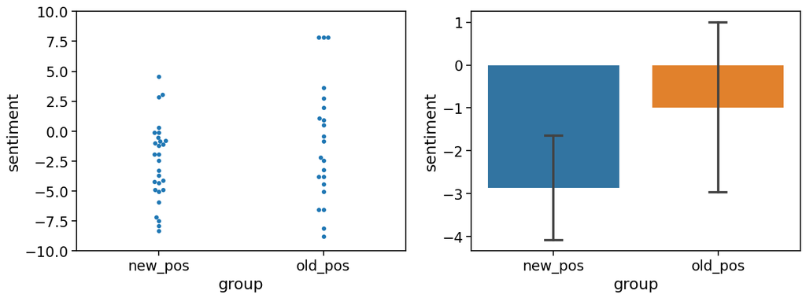

```python
matplotlib.pyplot.figure(figsize=(15,5))
matplotlib.pyplot.subplot(121)
plot = seaborn.swarmplot(x='group', y='sentiment', data=pos_sentiments)
plot.set_ylim([-10, 10])
matplotlib.pyplot.subplot(122)
plot = seaborn.barplot(x='group', y='sentiment', data=pos_sentiments, capsize=.1)
```

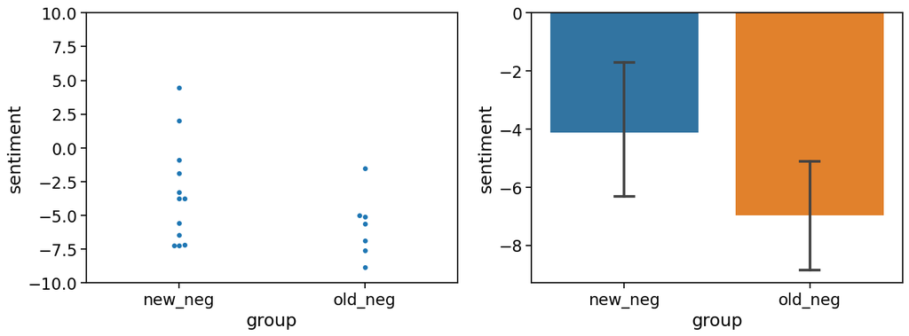

```python
matplotlib.pyplot.figure(figsize=(15,5))
matplotlib.pyplot.subplot(121)
plot = seaborn.swarmplot(x='group', y='sentiment', data=neg_sentiments)
plot.set_ylim([-10, 10])
matplotlib.pyplot.subplot(122)
plot = seaborn.barplot(x='group', y='sentiment', data=neg_sentiments, capsize=.1)
```

We can see that as a bar-plot, too, showing the 95% confidence intervals of the means.

## Step 7: Trying different lexicon

We will now be comparing the sentiment scores derived from two different lexicons (our original lexicon and SentiWordNet) across a set of terms, (essentially looking at paired observations). Each term receives two sentiment scores, one from each lexicon, under otherwise identical conditions. The goal is to determine if there's a statistically significant difference in the sentiment scores provided by the two lexicons.

```python
from nltk.corpus import sentiwordnet as swn

nltk.download('sentiwordnet')
nltk.download('wordnet')
```

```
True
```

```python
def words_to_swn_sentiment_separate(pos_terms, neg_terms):
    def calculate_sentiments(terms, group_label):
        sentiments = []
        for word in terms:
            word_lower = word.lower()  # Ensure lowercase for consistency
            synsets = list(swn.senti_synsets(word_lower))
            if not synsets:
                sentiment = 0  # Neutral if word not found
            else:
                # Aggregate scores across all senses
                pos_score = sum([synset.pos_score() for synset in synsets]) / len(synsets)
                neg_score = sum([synset.neg_score() for synset in synsets]) / len(synsets)
                sentiment = pos_score - neg_score  # Simple aggregation strategy
            sentiments.append({'word': word_lower, 'sentiment': sentiment, 'group': group_label})
        return pd.DataFrame(sentiments)

    # Process positive terms
    pos_frames = []
    for group, name_list in pos_terms.items():
        pos_frame = calculate_sentiments(name_list, group)
        pos_frames.append(pos_frame)
    pos_sentiments_swn = pd.concat(pos_frames, ignore_index=True)

    # Process negative terms
    neg_frames = []
    for group, name_list in neg_terms.items():
        neg_frame = calculate_sentiments(name_list, group)
        neg_frames.append(neg_frame)
    neg_sentiments_swn = pd.concat(neg_frames, ignore_index=True)

    return pos_sentiments_swn, neg_sentiments_swn

# Calculate sentiment scores using SentiWordNet for positive and negative terms separately
pos_sentiments_swn, neg_sentiments_swn = words_to_swn_sentiment_separate(pos_terms, neg_terms)
```

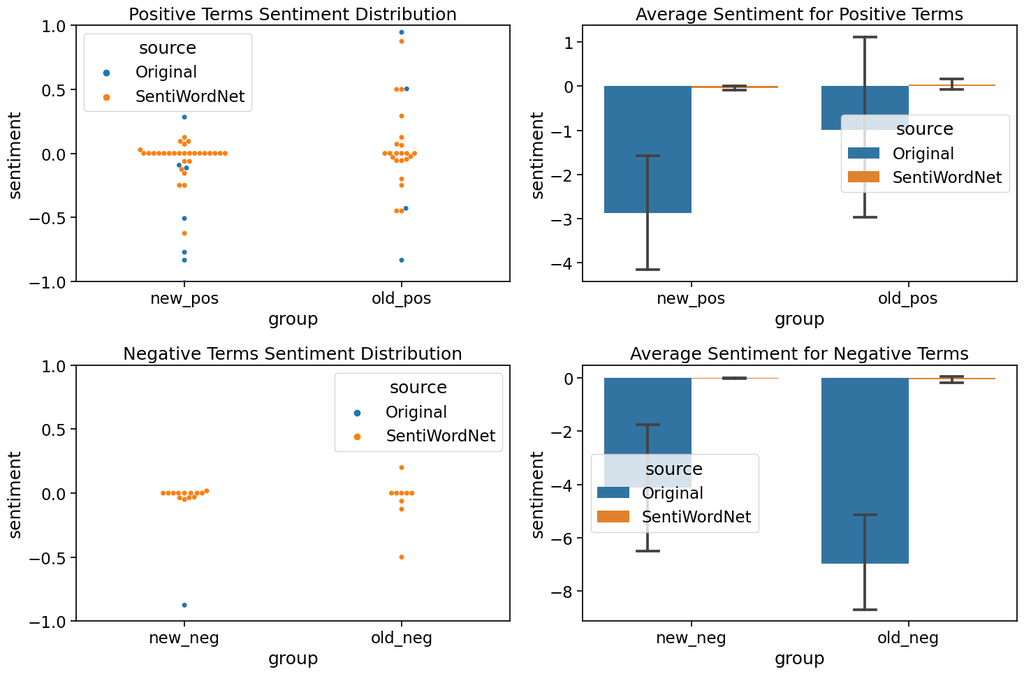

```python
pos_sentiments['source'] = 'Original'
pos_sentiments_swn['source'] = 'SentiWordNet'
combined_pos = pd.concat([pos_sentiments, pos_sentiments_swn])

neg_sentiments['source'] = 'Original'
neg_sentiments_swn['source'] = 'SentiWordNet'
combined_neg = pd.concat([neg_sentiments, neg_sentiments_swn])

# Positive terms visualization
matplotlib.pyplot.figure(figsize=(15, 10))
matplotlib.pyplot.subplot(221)
plot = seaborn.swarmplot(x='group', y='sentiment', hue='source', data=combined_pos)
plot.set_ylim([-1, 1])  # Adjusted for SentiWordNet score range
matplotlib.pyplot.title('Positive Terms Sentiment Distribution')

matplotlib.pyplot.subplot(222)
plot = seaborn.barplot(x='group', y='sentiment', hue='source', data=combined_pos, capsize=.1)
matplotlib.pyplot.title('Average Sentiment for Positive Terms')

# Negative terms visualization
matplotlib.pyplot.subplot(223)
plot = seaborn.swarmplot(x='group', y='sentiment', hue='source', data=combined_neg)
plot.set_ylim([-1, 1])  # Adjusted for SentiWordNet score range
matplotlib.pyplot.title('Negative Terms Sentiment Distribution')

matplotlib.pyplot.subplot(224)
plot = seaborn.barplot(x='group', y='sentiment', hue='source', data=combined_neg, capsize=.1)
matplotlib.pyplot.title('Average Sentiment for Negative Terms')

matplotlib.pyplot.tight_layout()
matplotlib.pyplot.show()
```

By applying the paired t-test, we can statistically evaluate whether the sentiment scores from two different lexicons significantly differ for the same set of terms. This analysis can help us understand the impact of lexicon choice on sentiment analysis outcomes.

```python
print(combined_pos.columns)
print(pos_sentiments.columns)
print(pos_sentiments_swn.columns)
```

```
Index(['word', 'sentiment', 'group', 'source'], dtype='object')
Index(['word', 'sentiment', 'group', 'source'], dtype='object')
Index(['word', 'sentiment', 'group', 'source'], dtype='object')
```

```python
from scipy.stats import ttest_rel

# Filter the combined DataFrame for original lexicon and SentiWordNet scores
original_scores = combined_pos[combined_pos['source'] == 'Original']
swn_scores = combined_pos[combined_pos['source'] == 'SentiWordNet']

# Ensure the words are in the same order for both sources
original_scores = original_scores.sort_values(by='word').reset_index(drop=True)
swn_scores = swn_scores.sort_values(by='word').reset_index(drop=True)

# Perform the paired t-test on sentiment scores
t_stat, p_value = ttest_rel(original_scores['sentiment'], swn_scores['sentiment'])

print(f"Paired t-test results: T-statistic = {t_stat}, P-value = {p_value}")
```

```
Paired t-test results: T-statistic = -3.536259275268141, P-value = 0.0008857694212579747
```

### **5. Present results from your analysis and provide evidence from the results that support or refute your hypothesis. Write a conclusion based upon the various analyses you performed. Be sure to reference your research questions systematically in your conclusion. With your analysis complete, are there any additional research questions or limitations to your conclusions?

This is not a complete test by any means, for further testing, we would like to use another lexicon that has some of the words that we are testing for, so that the test sample is not reduced. But what it does show, is that AI teams that are producing software based on similar lexicons and word embeddings will show some bias, against the most recent types of words used as well older ones. Hence, to eliminate this bias, one has to be extremely careful when using an AI system so that it does not misinterpret you.

### **6. Identify two conferences or journals that would be interested in the results of your analysis.

Given our reseaarch focuses on the ethical nature of AI and its implications regarding age bias, the following 2 journals could be helpful to get our works published:

1. Ethics and Information Technology
   - peer reviewed (credibility through scientific community)
   - focuses on fostering and promoting reflection and analysis of the ethical, social and political questions with the adoption of technology.
   - https://link.springer.com/journal/10676
2. Big Data and Society
   - peer reviewed (credibility through scientific community)
   - open access (more views)
   - focuses on providing a platform to debate the implications on academic, social, industry and business relations in terms of usage of big data.
   - https://journals.sagepub.com/description/BDS